# Comparing velocity packages

Brunno Oliveira

05 September, 2023

# 1 setup

```r
# devtools::install_github("cbrown5/vocc")
# devtools::install_github("oliveirab/VoCC", build_vignettes = FALSE)

list.of.packages <- c("climetrics","vocc","VoCC1","terra","ggplot2","GGally","data.table")
# new.packages <- list.of.packages[!(list.of.packages %in% installed.packages()[,"Package"])]
# if(length(new.packages)) install.packages(new.packages)
sapply(list.of.packages, require, character.only = TRUE)
```

```
## climetrics       vocc      VoCC1      terra    ggplot2     GGally data.table
##       TRUE       TRUE       TRUE       TRUE       TRUE       TRUE       TRUE
```

```r
# Source velocity functions adapted from the package climetrics after applying some corrections described below
# source("/storage/simple/projects/t_cesab/brunno/Exposure-SDM/R/velocity_functions.R")
source(here::here("R/velocity_functions.R"))
# Source function generated by Gael to create the spatial gradient at the latitudinal direction.
source(here::here("R/gael_velocity.R"))
# Source settings (here used only to the Eckert equal area projection)
source(here::here("R/settings.R"))
```

In order to generate comparable results across multiple R packages, we sourced climate data from the package `climetrics.` These represent monthly mean annual temperature from Jan 1991 to Dec 2020. The geographical area covers North of France, Great Britain and West of Norway.

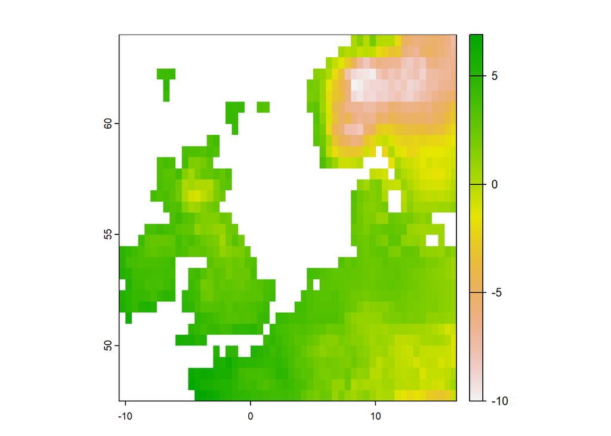

```r
# path to the dataset folder
filePath <- system.file("external/", package="climetrics")
tmean <- rast(paste0(filePath,'/tmean.tif'))
plot(tmean[[1]])
```

```r
# corresponding dates
n <- readRDS(paste0(filePath,'/dates.rds'))

# get averages per year
terra::time(tmean) <- as.Date(n)
tmean <- tapp(tmean, "years", mean)

# project to equal area
tmean <- terra::project(tmean,Eckt)
```

# 2 Calculate velocities

## 2.1 `Climetrics`

This package is based on the package vocc (not VoCC!). I found that both packages have an issue when calculating the spatial gradient. The issue is that when extracting environmental data from the RasterStack they use only the first year to calculate the spatial gradient. Instead, the package VoCC uses the mean of all years (calc(r,mean)), which is the correct thing to do! To prove this issue, I calculate velocity with this package using the both the default (wrong) method and the corrected procedure (using mean raster).

```r
start <- Sys.time()

### Wrong way
# Velocity
v_climetrics1 <- climetrics:::gVelocity(tmean)

climetrics_time <- Sys.time() - start

# Spatial gradient (wrong way)
spgrad_climetrics1 <- climetrics:::.spatialgradTerra(tmean)

spgrad_climetrics1$NS[is.na(spgrad_climetrics1$NS)] <- 0
spgrad_climetrics1$WE[is.na(spgrad_climetrics1$WE)] <- 0
spgrad_climetrics1$NAsort <- ifelse((abs(spgrad_climetrics1$NS)+abs(spgrad_climetrics1$WE)) == 0, NA, 1)
spgrad_climetrics1$Grad <- spgrad_climetrics1$NAsort * sqrt((spgrad_climetrics1$WE^2) + (spgrad_climetrics1$NS^2))

# Angles
angle_climatrics1 <- spgrad_climetrics1$angle


### Right way
# Trend
trend_climatrics <- climetrics:::.tempgradTerra(tmean)
# Spatial gradient
spgrad_climetrics2 <- climetrics:::.spatialgradTerra(mean(tmean))

spgrad_climetrics2$NS[is.na(spgrad_climetrics2$NS)] <- 0
spgrad_climetrics2$WE[is.na(spgrad_climetrics2$WE)] <- 0
spgrad_climetrics2$NAsort <- ifelse((abs(spgrad_climetrics2$NS)+abs(spgrad_climetrics2$WE)) == 0, NA, 1)
spgrad_climetrics2$Grad <- spgrad_climetrics2$NAsort * sqrt((spgrad_climetrics2$WE^2) + (spgrad_climetrics2$NS^2))

# Angles
angle_climatrics2 <- spgrad_climetrics2$angle

# Velocity
v_climetrics2 <- climetrics:::.calcvelocity(grad = spgrad_climetrics2,
                                            slope = trend_climatrics,
                                            .terra = TRUE)
```

## 2.2 `vocc`

Note that the same issue described above happens here. Thus, I calculate velocity with this package using the both the default (wrong) and the correct procedure (using mean raster).

```r
# Trend
start <- Sys.time()

trend_vocc = vocc::calcslope(rx = stack(tmean),
                             divisor = 1) # to get C/year

### Wrong way
# Spatial gradient
spgrad_out_vocc1 = vocc::spatialgrad(rx = stack(tmean),
                                     y_dist = res(tmean),
                                     y_diff = NA)
# Angle
angle_vocc1 = spgrad_out_vocc1$angle

# Calculating temperature velocity
v_vocc1 = vocc::calcvelocity(grad = spgrad_out_vocc1,
                             slope = trend_vocc)
v_vocc_rast1 <- rast(tmean[[1]])
v_vocc_rast1[] <- v_vocc1$velocity

vocc_time <- Sys.time() - start

### Right way
# spatial gradient
spgrad_out_vocc2 = vocc::spatialgrad(rx = stack(mean(tmean)),
                                     y_dist = res(tmean),
                                     y_diff = NA)
# Angle
angle_vocc2 = spgrad_out_vocc2$angle

# Calculating temperature velocity
v_vocc2 = vocc::calcvelocity(grad = spgrad_out_vocc2,
                             slope = trend_vocc)
v_vocc_rast2 <- rast(tmean[[2]])
v_vocc_rast2[] <- v_vocc2$velocity
```

## 2.3 `VoCC`

```r
start <- Sys.time()

# calculate the trend
trend_VoCC = VoCC1::tempTrend(r = stack(tmean),
                              th = 0.25*nlyr(tmean) ## set minimum # obs. to 1/4 time series length
)

# calculate the spatial gradient
spgrad_VoCC = VoCC1::spatGrad(r = stack(tmean),
                              projected = TRUE)

# Calculating temperature velocity
v_VoCC = VoCC1::gVoCC(tempTrend = trend_VoCC,
                      spatGrad = spgrad_VoCC)

# Angle
angle_VoCC = values(spgrad_VoCC[[2]])

VoCC_time <- Sys.time() - start
```

## 2.4 `Bioshifts`

```r
start <- Sys.time()

# Trend
trend_bio <- temp_grad(tmean, th = 0.25*nlyr(tmean))

# Spatial gradient
spgrad_bio <- spatial_grad(tmean)

# Velocity
v_bio <- gVelocity(spgrad_bio,trend_bio)

# Angle
angle_bio = spgrad_bio$angle

bio_time <- Sys.time() - start
```

## 2.5 Gael’s function

```r
# spatial gradient
spgrad_gael <- Gael_grad(stack(tmean))
# trend (use VoCC trend function)
trend_gael <- VoCC1::tempTrend(r = stack(tmean), th = 10)
trend_gael = resample(trend_gael, spgrad_gael)

v_gael = trend_gael[[1]] / spgrad_gael
v_gael = resample(v_gael, stack(tmean))
```

# 3 Extra

This tests whether we can calculate the velocity in the North direction using the gradient North provided in the output, or if it isn necessary to convert the angle of the velocity to the North direction. According to the calculations below, we can use the gradient North directly. It is not necessary to convert velocity rates to the North direction using angles.

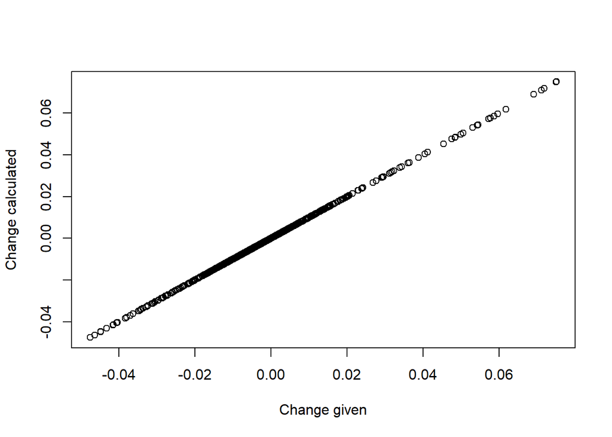

```r
# get data
v_data <- as.data.frame(spgrad_bio)
v_data <- na.omit(v_data)

# Convert gradients to the North direction using the angle
temperature_change_rate <- v_data$Grad  # °C/km
vel_angle <- v_data$angle

angle_degrees_NS <- vel_angle+90        # degrees (+90 transforms 0 to North angle and 90 the East angle)
angle_degrees_WE <- vel_angle-90        # degrees (-90 transforms 90 to West angle and 0 to the South angle)

# Convert angle to radians
angle_radians_NS <- angle_degrees_NS * pi / 180
angle_radians_WE <- angle_degrees_WE * pi / 180

# Calculate temperature change in North and West directions
temperature_change_north <- temperature_change_rate * sin(angle_radians_NS)
temperature_change_west <- temperature_change_rate * cos(angle_radians_WE)

plot(v_data$NS,temperature_change_north,
     xlab="Change given",ylab = "Change calculated")
```

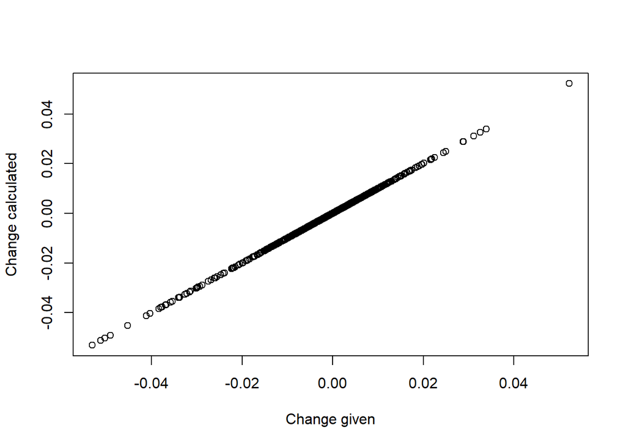

```r
plot(v_data$WE,temperature_change_west,
     xlab="Change given",ylab = "Change calculated")
```

See! Use NS/WE directly.

# 4 Compare results

## 4.1 Velocities maps

```r
tmp <- rast(c(climetrics1=v_climetrics1,
              climetrics2=v_climetrics2,
              vocc1=v_vocc_rast1,
              vocc2=v_vocc_rast2,
              VoCC=rast(v_VoCC[[1]]),
              v_bio=v_bio))
# very different values
tmp
```

```
## class       : SpatRaster
## dimensions  : 37, 54, 6  (nrow, ncol, nlyr)
## resolution  : 40533.1, 40533.1  (x, y)
## extent      : -851881.8, 1336905, 5819336, 7319061  (xmin, xmax, ymin, ymax)
## coord. ref. : +proj=eck4 +lon_0=0 +x_0=0 +y_0=0 +datum=WGS84 +units=m +no_defs
## source(s)   : memory
## names       : climetrics1, climetrics2,       vocc1,       vocc2,     VoCC,       v_bio
## min values  :    6.847561,    6.852917,    148.8258,    146.0861, 146.0861,   0.1460861
## max values  :  219.375831,  199.172212, 289431.4234, 129722.9667,      Inf, 129.7229667
```

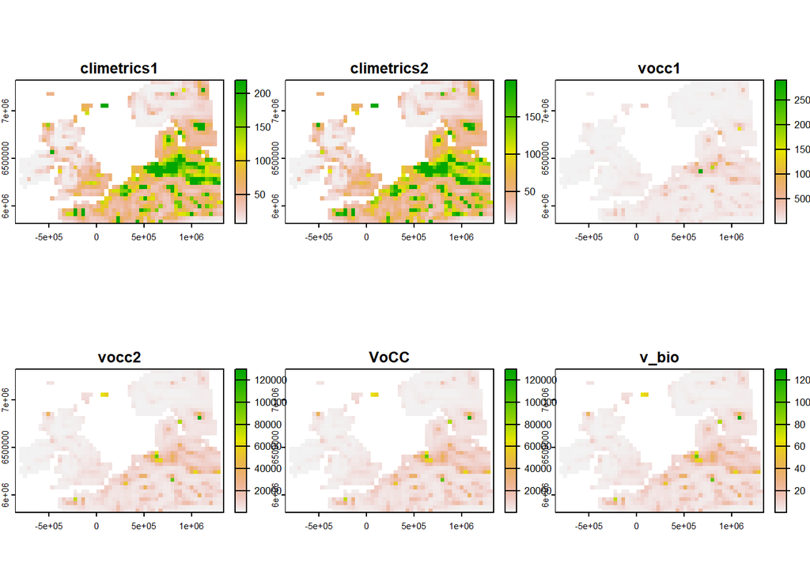

```r
plot(tmp)
```

## 4.2 Velocities correlations

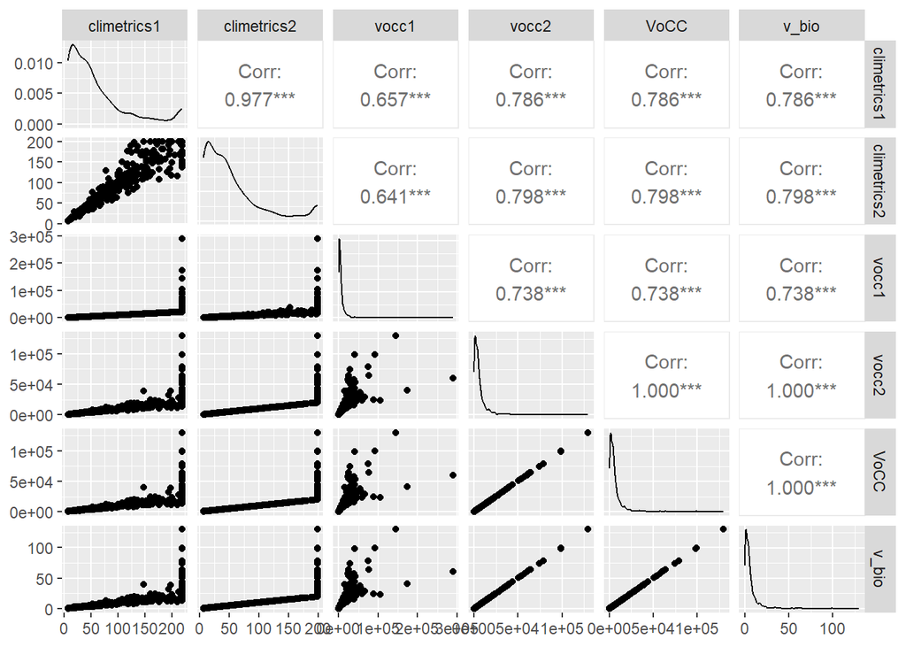

```r
velocities <- data.frame(tmp)

ggpairs(velocities)
```

## 4.3 Time for calculating velocities

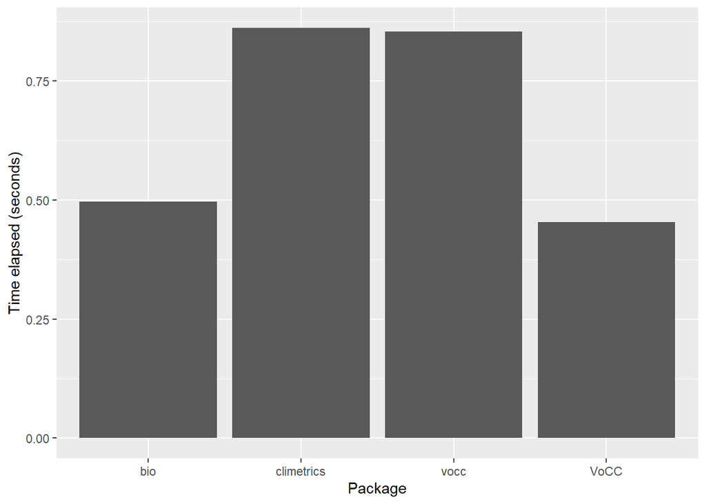

```r
timesFuncs <- data.frame(t(data.frame(climetrics_time[[1]],vocc_time[[1]],VoCC_time[[1]],bio_time[[1]])))
names(timesFuncs) <- "elapsed"
timesFuncs$Package <- gsub("_time..1..","",rownames(timesFuncs))

ggplot(timesFuncs, aes(x = Package, y = elapsed))+
    geom_col() + ylab("Time elapsed (seconds)")
```

# 5 North direction velocities

Here, we can add Gael’s results for North velocity

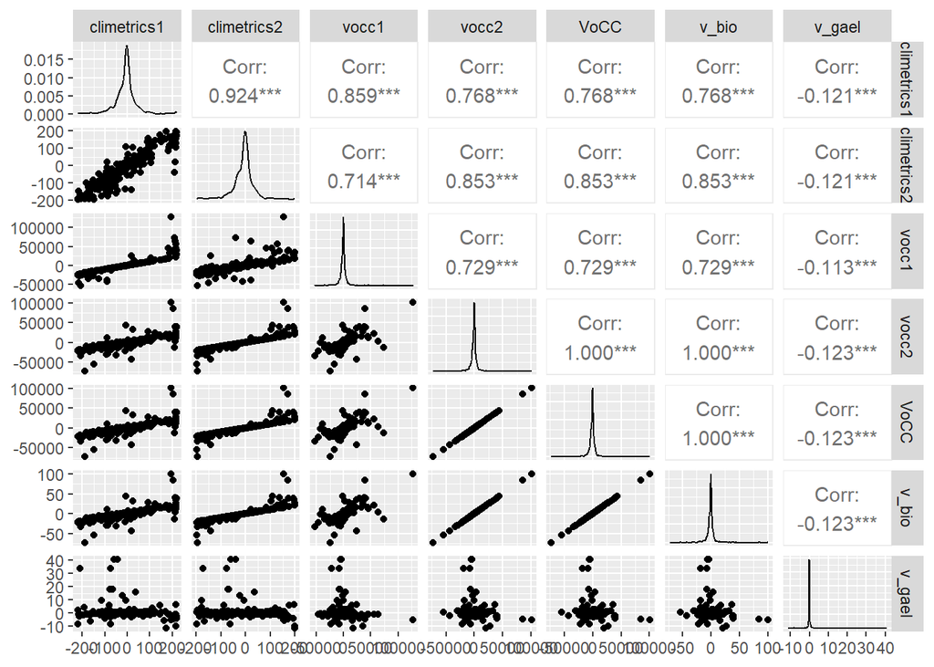

```r
# Convert all velocities to the North direction
velocities_North <- data.frame(
    climetrics1=values(v_climetrics1)[,1] * sin(angle_climatrics1 * pi / 180),
    climetrics2=values(v_climetrics2)[,1] * sin(angle_climatrics2 * pi / 180),
    vocc1=values(v_vocc_rast1)[,1] * sin(angle_vocc1 * pi / 180),
    vocc2=values(v_vocc_rast2)[,1] * sin(angle_vocc2 * pi / 180),
    VoCC=raster::values(v_VoCC[[1]]) * sin(angle_VoCC * pi / 180),
    v_bio=values(v_bio)[,1] * sin(angle_bio * pi / 180),
    v_gael=values(rast(v_gael))[,1])

ggpairs(velocities_North)
```

VoCC and bioshifts still identical. Gael’s code generates very different results.

## 5.1 Compare velocities with projected and unprojected raster files

```r
# Use the same set of climate variables
tmean <- rast(paste0(filePath,'/tmean.tif'))
# project to equal-area
tmean_proj <- terra::project(tmean,Eckt)

# Use rts function in the rts package to make a raster time series:
tmean.t <- rts(tmean,n)
tmean.t_proj <- rts(tmean_proj,n)


####
# VoCC unprojected
# Trend
trend_VoCC = VoCC1::tempTrend(r = stack(tmean),
                              th = 0.25*nlyr(tmean))

# Spatial gradient
spgrad_VoCC = VoCC1::spatGrad(r = stack(tmean),
                              projected = FALSE)

# Velocity
v_VoCC = VoCC1::gVoCC(tempTrend = trend_VoCC,
                      spatGrad = spgrad_VoCC)

####
# VoCC projected
# Trend
trend_VoCC = VoCC1::tempTrend(r = stack(tmean_proj),
                              th = 0.25*nlyr(tmean_proj) ## set minimum # obs. to 1/4 time series length
)
# Spatial gradient
spgrad_VoCC = VoCC1::spatGrad(r = stack(tmean_proj),
                              projected = TRUE)
# Velocity
v_VoCC2 = VoCC1::gVoCC(tempTrend = trend_VoCC,
                       spatGrad = spgrad_VoCC)

## Compare velocities
v_VoCC[[1]]
```

```
## class      : RasterLayer
## dimensions : 33, 54, 1782  (nrow, ncol, ncell)
## resolution : 0.5, 0.5  (x, y)
## extent     : -10.5, 16.5, 47.5, 64  (xmin, xmax, ymin, ymax)
## crs        : +proj=longlat +datum=WGS84 +no_defs
## source     : memory
## names      : voccMag
## values     : 0.02282359, 9.904595  (min, max)
```

```r
v_VoCC2[[1]]
```

```
## class      : RasterLayer
## dimensions : 37, 54, 1998  (nrow, ncol, ncell)
## resolution : 40533.1, 40533.1  (x, y)
## extent     : -851881.8, 1336905, 5819336, 7319061  (xmin, xmax, ymin, ymax)
## crs        : +proj=eck4 +lon_0=0 +x_0=0 +y_0=0 +datum=WGS84 +units=m +no_defs
## source     : memory
## names      : voccMag
## values     : 24.77245, Inf  (min, max)
```

```r
####
# bioshifts unprojected
# Trend
trend_bio <- temp_grad(tmean, th = 0.25*nlyr(tmean))
# Spatial gradient
spgrad_bio <- spatial_grad(tmean)
# Velocity
v_bio <- gVelocity(spgrad_bio,trend_bio)

####
# bioshifts projected
# Trend
trend_bio <- temp_grad(tmean_proj, th = 0.25*nlyr(tmean_proj))
# Spatial gradient
spgrad_bio <- spatial_grad(tmean_proj)
# Velocity
v_bio2 <- gVelocity(spgrad_bio,trend_bio)

## Compare velocities
v_bio
```

```
## class       : SpatRaster
## dimensions  : 33, 54, 1  (nrow, ncol, nlyr)
## resolution  : 0.5, 0.5  (x, y)
## extent      : -10.5, 16.5, 47.5, 64  (xmin, xmax, ymin, ymax)
## coord. ref. : lon/lat WGS 84 (EPSG:4326)
## source(s)   : memory
## name        :    GradVel
## min value   : 0.02273675
## max value   : 9.79551874
```

```r
v_bio2
```

```
## class       : SpatRaster
## dimensions  : 37, 54, 1  (nrow, ncol, nlyr)
## resolution  : 40533.1, 40533.1  (x, y)
## extent      : -851881.8, 1336905, 5819336, 7319061  (xmin, xmax, ymin, ymax)
## coord. ref. : +proj=eck4 +lon_0=0 +x_0=0 +y_0=0 +datum=WGS84 +units=m +no_defs
## source(s)   : memory
## name        :     GradVel
## min value   :  0.02477244
## max value   : 12.48713230
```

## 5.2 Why VoCC results are different when using projected and unprojected data?

```r
summary(v_VoCC[[1]])
```

```
##              voccMag
## Min.      0.02282359
## 1st Qu.   0.16517678
## Median    0.34051253
## 3rd Qu.   0.63029609
## Max.      9.90459499
## NA's    726.00000000
```

```r
summary(v_VoCC2[[1]]/1000)
```

```
##              voccMag
## Min.      0.02477245
## 1st Qu.   0.18575202
## Median    0.39378280
## 3rd Qu.   0.69185021
## Max.             Inf
## NA's    846.00000000
```